# Repeated Measures and Mixed Models

## Introduction

Some are still trained in statistics with a heavy focus on so-called analysis of variance (ANOVA) techniques, but without delving too much (or at least, enough) into their role as special cases of regression, and mixed models more generally. This is despite the fact that data collected is typically richer than a couple of tightly controlled treatment conditions with a continuous target variable, rendering these techniques too restrictive for many common situations. The following uses a very small dataset to demonstrate the connections to standard linear and mixed models, with a hope that some will consider using the more general approaches after realizing they are only gaining in flexibility while maintaining the same analyses of interest they are already using.

## Data Setup

Let’s look at some simple data in which the effect is *eyeballable*. We will use it in both wide format, where a row would represent a single observational unit, and long format, where multiple rows belong to the observational unit.

```r
library(dplyr)
treat  = rep(c('treat', 'control'), e=5)
pre = c(20,10,60,20,10,50,10,40,20,10)
post = c(70,50,90,60,50,20,10,30,50,10)

df = data.frame(id=factor(1:10), treat, pre, post)
change = post-pre

dflong = tidyr::gather(df, key=time, value=score, pre:post) %>% arrange(id)
head(df)
```

```
  id   treat pre post
1  1   treat  20   70
2  2   treat  10   50
3  3   treat  60   90
4  4   treat  20   60
5  5   treat  10   50
6  6 control  50   20
```

```r
head(dflong)
```

```
  id treat time score
1  1 treat  pre    20
2  1 treat post    70
3  2 treat  pre    10
4  2 treat post    50
5  3 treat  pre    60
6  3 treat post    90
```

When I meant the effect is eyeballable, everyone in the treatment group improves from pre to post, while controls are mixed at best, and this effect is visually obvious. I should note that when patterns are this obvious, the compulsion to do statistical tests should be stifled. We only do so here for expository reasons.

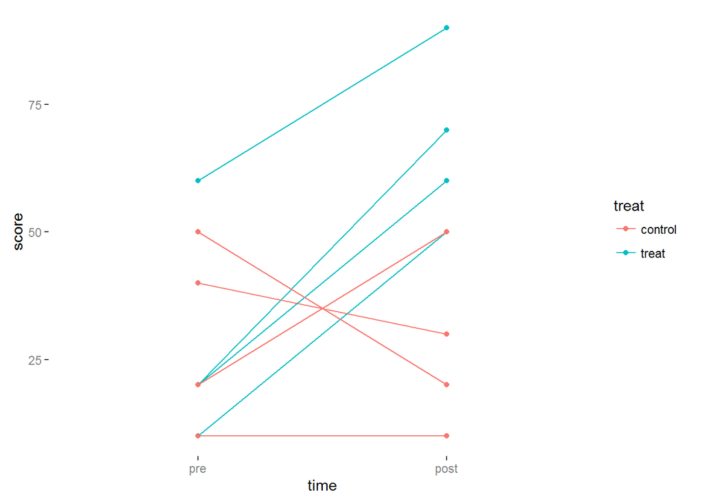

## Between Groups Approach

### t-test

Ignoring the correlated nature of the data for now, we will show the simple regression of post score on treatment to show how the different approaches can produce identical results.

```r
ttestModel = t.test(post ~ treat, data=df, var.equal=T)
ttestModel
```

```
    Two Sample t-test

data:  post by treat
t = -3.7796, df = 8, p-value = 0.005391
alternative hypothesis: true difference in means is not equal to 0
95 percent confidence interval:
 -64.40445 -15.59555
sample estimates:
mean in group control   mean in group treat
                   24                    64
```

```r
ttestModel$statistic^2
```

```
       t
14.28571
```

### ANOVA

Now for the ANOVA, which is identical.

```r
anovaModelPostOnly = aov(post ~ treat, df)
summary(anovaModelPostOnly)
```

```
            Df Sum Sq Mean Sq F value  Pr(>F)
treat        1   4000    4000   14.29 0.00539 **
Residuals    8   2240     280
---
Signif. codes:  0 '***' 0.001 '**' 0.01 '*' 0.05 '.' 0.1 ' ' 1
```

```r
coef(anovaModelPostOnly)
```

```
(Intercept)  treattreat
         24          40
```

$t^2 = F$, with identical p-values.

### Standard Regression

Now for the standard linear model (SLiM).

```r
lmModelPostOnly = lm(post ~ treat, df)
summary(lmModelPostOnly)
```

```
Call:
lm(formula = post ~ treat, data = df)

Residuals:
   Min     1Q Median     3Q    Max
   -14    -14     -4      6     26

Coefficients:
            Estimate Std. Error t value Pr(>|t|)
(Intercept)   24.000      7.483   3.207  0.01248 *
treattreat    40.000     10.583   3.780  0.00539 **
---
Signif. codes:  0 '***' 0.001 '**' 0.01 '*' 0.05 '.' 0.1 ' ' 1

Residual standard error: 16.73 on 8 degrees of freedom
Multiple R-squared:  0.641, Adjusted R-squared:  0.5962
F-statistic: 14.29 on 1 and 8 DF,  p-value: 0.005391
```

```r
coef(lmModelPostOnly)
```

```
(Intercept)  treattreat
         24          40
```

The intercept is the mean for the reference group, while the coefficient for group is the difference between their respective means. The t for the coefficient (and associated p-value) is identical to the t from the t-test (sign is arbitrary depending on how the labels are used), while the overall model F in the regression is the same as in the ANOVA. This equivalence is explicit in R, as the `aov` function actually calls the `lm` function, and the class of an aov object is both ‘aov’ and ‘lm’. I guess I should point out that SAS and SPSS ANOVA tables default to a sums of squares approach that is not equivalent to a SLiM in the presence of interactions (and which some would say doesn’t make much sense). See the help file for `Anova` in the car package for details. The point here is simply that we have run the same model three different ways, but produced identical results in each case.

## Pre-Post Design

Now let’s incorporate the pre-post nature of the data. We’ll start with a t-test on the change from pre to post. Our target variable is the change score (sometimes called the gain or difference score).

### t-test

```r
ttestChange = t.test(change ~ treat, df, var.equal=T)
ttestChange
```

```
    Two Sample t-test

data:  change by treat
t = -4.1184, df = 8, p-value = 0.003351
alternative hypothesis: true difference in means is not equal to 0
95 percent confidence interval:
 -65.51672 -18.48328
sample estimates:
mean in group control   mean in group treat
                   -2                    40
```

```r
ttestChange$statistic^2
```

```
       t
16.96154
```

### ANCOVA

An alternative approach is ANCOVA, which changes the substantive emphasis to examining post-test scores while controlling for pre-test. The target variable is thus fundamentally different than in the previous model (raw vs. change). However, note that an ANCOVA is a sequential regression model that examines the treatment effect while controlling for pretest scores.

```r
ancova = aov(post~ pre + treat)
ancovalm = lm(post~ pre + treat)
rbind(coef(ancova), coef(ancovalm))
```

```
     (Intercept)       pre treattreat
[1,]    10.31579 0.5263158   41.05263
[2,]    10.31579 0.5263158   41.05263
```

Again the outcomes are identical, as `aov` uses `lm` under the hood.

Since Lord’s Paradox was introduced, there has been some back and forth among various papers ever since debating whether one should use ANCOVA vs. t-test on change scores. Aside from it not really being a paradox (both statisticians are correct), it’s unclear to me that the debate is very useful for applied researchers for various reasons. For one, I’ve never seen a study in which I’d be interested in the results of a t-test. At best it tells an overly simplistic story, and we have far better, and as easily implemented, tools to help us understand the complexities of nature. As such, a t-test on gain scores is at best used as a descriptive statistic. Some are concerned about statistical power, but basing your assessment of treatment viability based solely on an arbitrary p-value cutoff is borderline unethical for some lines of research (in my opinion), so that shouldn’t be the overriding concern either. In addition, whether observational or experimental, a statistical result will not tell you about causal relations. You can, however, specify those causal effects that you think exist and run a model appropriate to the situation, focusing on the specific effect of interest. In this case the t-test and ANCOVA can be seen as different effects, *total* and *direct* respectively, from the same causal model (see [Pearl, 2014](http://ftp.cs.ucla.edu/pub/stat_ser/r436.pdf), and the example of it in the appendix). As such, conducting separate power analyses for the t-test vs. ANCOVA makes no sense, as they belong to the same model, and can also be (essentially) equivalent if pre and post are strongly correlated.

Statistically speaking, as we will also see, both approaches are special cases of more flexible models that can better handle the nuances of the typical, more complex data situation in which there are multiple predictors, interactions of interest, nonlinear relationships, or more than two time points, etc., such that neither would be appropriate for many situations. But statistically, ANCOVA is no different than the SLiM, so it only has the issues that the SLiM has. A t-test on change scores is part of a repeated measures ANOVA result that is a special case of mixed models, which themselves generalize the SLiM.

### Repeated Measures Anova

Now that we’ve gone through that, let’s do a repeated measures ANOVA with treatment as the between subjects effect and score as the repeated measure (pre-post).

```r
anovaModelRM = aov(score ~ treat*time + Error(id), dflong)
summary(anovaModelRM)
```

```
Error: id
          Df Sum Sq Mean Sq F value Pr(>F)
treat      1   1805    1805   3.406  0.102
Residuals  8   4240     530

Error: Within
           Df Sum Sq Mean Sq F value  Pr(>F)
time        1   1805    1805   13.88 0.00582 **
treat:time  1   2205    2205   16.96 0.00335 **
Residuals   8   1040     130
---
Signif. codes:  0 '***' 0.001 '**' 0.01 '*' 0.05 '.' 0.1 ' ' 1
```

Note that the interaction F-value here is the squared value of the t-test on the change scores (-4.12<sup>2</sup>). In other words, a t-test on the change score is the interaction term from the repeated measures ANOVA on the same data.

### Mixed Model

From the mixed model, we also use the long form of data. We’ll use an R package specifically for mixed models, lme4, but R comes with the nlme package that could also be used.

```r
library(lme4)
lmeModel = lmer(score ~ treat*time + (1|id), data=dflong)
anova(lmeModel)
```

```
Analysis of Variance Table
           Df  Sum Sq Mean Sq F value
treat       1  442.74  442.74  3.4057
time        1 1805.00 1805.00 13.8846
treat:time  1 2205.00 2205.00 16.9615
```

While the estimation approaches are different, the end results are the same as with the ANOVA. However, now we are using a tool that can handle additional time points, continuous covariates with possibly nonlinear relationships, different types of outcome variables, other correlational structures among the observations, etc. In fact, if one looks at the help file for `aov`, one will note that it suggests using `lme` for unbalanced designs and other situations (see the appendix for additional examples).

## Summary

In general, standard ANOVA techniques are special cases of modeling approaches that are far more flexible, extensible, and often just as easy to use. R is useful because just a simple inspection of the help file for the `aov` function makes clear the ties to linear and linear mixed models. If one has a straightforward experimental design and is not interested in exploring complex interactions or dealing with data nuances, the ‘sums of squares’ approach may be adequate. What’s happened in the past (e.g. within psychology departments), is that people were taught statistics with a strong focus on ANOVA, but who were not likely going to do experiments. This resulted in students forcing their data to conform to the technique (e.g. target variable transforms, categorizing numeric covariates), rather than finding a suitable techniques for how their data is represented. While such teaching seems far less the case these days (thankfully!), some are still taught that way or are not given enough time to learn during their short statistical exposure how to generalize beyond simple settings. Hopefully this document can help a bit in that case.

## Appendix

### t-test vs. ANCOVA: different paths of the same model

Consider the following mediation models. The image is taken from Pearl (2014), where in our case S is the treatment and $W_i$ is our pretest, and $W_f$ is our posttest. $Y$ represents the change score, but is not necessary to explicitly model for our purposes.

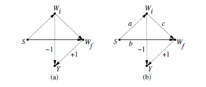

We will model this as a structural equation model, with pretest serving as a means for an indirect effect of treatment. The t-test on the change score we saw earlier is the total effect in this scenario: it is the direct effect *b*, plus the indirect effect *a*c*, minus the initial path *a*. The direct effect *b* is what we get in the ANCOVA.

```r
# pearl lords paradox

mod = "
  pre ~ a*treat
  post ~ b*treat + c*pre
  # change ~ -1*pre + 1*post

  # total effect
  TE := (b + a*c) - a
"

library(lavaan)
lpmod = sem(mod, data=df)

summary(lpmod)
```

```
lavaan (0.5-20) converged normally after  40 iterations

  Number of observations                            10

  Estimator                                         ML
  Minimum Function Test Statistic                0.000
  Degrees of freedom                                 0

Parameter Estimates:

  Information                                 Expected
  Standard Errors                             Standard

Regressions:
                   Estimate  Std.Err  Z-value  P(>|z|)
  pre ~
    treat      (a)   -2.000   11.027   -0.181    0.856
  post ~
    treat      (b)   41.053    7.490    5.481    0.000
    pre        (c)    0.526    0.214    2.454    0.014

Variances:
                   Estimate  Std.Err  Z-value  P(>|z|)
    pre             304.000  135.953    2.236    0.025
    post            139.789   62.516    2.236    0.025

Defined Parameters:
                   Estimate  Std.Err  Z-value  P(>|z|)
    TE               42.000    9.121    4.605    0.000
```

```r
summary(lm(change~treat, df))  # t-test on change scores = total effect
```

```
Call:
lm(formula = change ~ treat, data = df)

Residuals:
   Min     1Q Median     3Q    Max
   -28     -6      0      2     32

Coefficients:
            Estimate Std. Error t value Pr(>|t|)
(Intercept)   -2.000      7.211  -0.277  0.78854
treattreat    42.000     10.198   4.118  0.00335 **
---
Signif. codes:  0 '***' 0.001 '**' 0.01 '*' 0.05 '.' 0.1 ' ' 1

Residual standard error: 16.12 on 8 degrees of freedom
Multiple R-squared:  0.6795,    Adjusted R-squared:  0.6394
F-statistic: 16.96 on 1 and 8 DF,  p-value: 0.003351
```

```r
summary(lm(post~treat+pre, df)) # 'ancova' uncovers direct effect etc.
```

```
Call:
lm(formula = post ~ treat + pre, data = df)

Residuals:
    Min      1Q  Median      3Q     Max
-16.632  -6.368  -3.737   4.947  29.158

Coefficients:
            Estimate Std. Error t value Pr(>|t|)
(Intercept)  10.3158     9.1840   1.123  0.29838
treattreat   41.0526     8.9522   4.586  0.00253 **
pre           0.5263     0.2563   2.054  0.07912 .
---
Signif. codes:  0 '***' 0.001 '**' 0.01 '*' 0.05 '.' 0.1 ' ' 1

Residual standard error: 14.13 on 7 degrees of freedom
Multiple R-squared:  0.776, Adjusted R-squared:  0.712
F-statistic: 12.12 on 2 and 7 DF,  p-value: 0.005321
```

This shows that the question isn’t about whether to use change scores or control for baseline with ANCOVA/regression. The change score is defined as a weighted combination of pre and post scores, which the model ultimately regards.

### t-test vs. ANCOVA: an equivalence

Set **n** to very large and the estimates will converge. The values may be pretty close even without the transform, which just makes it exact with large N. Again, this assumes a notable correlation between pre and post, but that’s typically the case. Note also, that this assumes zero correlation between treatment condition and pre-test score, which should be the case in the experimental setting. The issue with regard to Lord’s Paradox revolves around the situation in which groups are different at baseline/pre.

```r
# setup
set.seed(12)
n = 1000
pre = rnorm(n)
treat = rep(0:1, e=n/2)
post = 1*pre + .25*treat + rnorm(n)
df = data.frame(treat, pre, post)
df %>% group_by(treat) %>% summarise(mean(pre), mean(post))
```

```
Source: local data frame [2 x 3]

  treat   mean(pre) mean(post)
  (int)       (dbl)      (dbl)
1     0 -0.02285966 0.01079596
2     1 -0.03001336 0.25611457
```

```r
# create transform value; see Knapp & Schafer 2009
# variances
varPre = var(pre)
varPost = var(post)

varWithinPre = df %>% group_by(treat) %>%  summarise(varr = var(pre))
varWithinPre = mean(varWithinPre$varr)
varWithinPost = df %>% group_by(treat) %>%  summarise(varr = var(post))
varWithinPost = mean(varWithinPost$varr)

# correlations
corPrePost = cor(pre, post); corPrePost
```

```
[1] 0.6767847
```

```r
corGroups = df %>% group_by(treat) %>%  summarise(corr = cor(pre,post))
corWithin = corGroups %$% sqrt(sum(corr^2)/2)

# transformation value
Anum =
  ( ((n-1)*varPost*(1-corPrePost^2))/
    ((n-2)*varWithinPost*(1-corWithin^2))  -1)
Adenom = ((n-1)*(varPre + varPost - 2*corPrePost*sqrt(varPre)*sqrt(varPost))) /
            ((n-2)*(varWithinPre + varWithinPost - 2*corWithin*sqrt(varWithinPre)*sqrt(varWithinPost))) -1

A = (n-3)/(n-2) * Anum/Adenom


# grab relevant statistics
ttestChange = t.test(post-pre~treat, data=df, var.equal=T)
ancova = aov(post~ pre + treat, data=df)
ancovaF = summary(ancova)[[1]]$F[2]
tF = ttestChange$statistic^2

c(tConverted = tF*A, ancovaF=ancovaF)
```

```
tConverted.t      ancovaF
    15.11989     15.11698
```

The idea here can be explained with reference to the previous path model example. Let’s rewrite the total effect as follows:

```r
"
.
.
.
  TE := b - a(1 - c)
"
```

If we refer to the previous example we don’t have to think in terms of an ad hoc adjustment. Relative to the path model noted, in this setting we are essentially setting moving path *c* closer to a value of 1, which results in the total effect being equivalent to *b*.

### More mixed model, repeated measures anova equivalence

```r
library(nlme)
fm1BW.lme <- lme(Reaction ~ Days, sleepstudy, random = ~ 1|Subject)
fm1BW.lmeSphere <- update(fm1BW.lme, correlation = corCompSymm(form = ~ Days|Subject))

anova(fm1BW.lme)
```

```
            numDF denDF   F-value p-value
(Intercept)     1   161 1087.9793  <.0001
Days            1   161  169.4014  <.0001
```

```r
anova(fm1BW.lmeSphere)
```

```
            numDF denDF   F-value p-value
(Intercept)     1   161 1087.9793  <.0001
Days            1   161  169.4014  <.0001
```

```r
summary(aov(Reaction ~ Days + Error(Subject), sleepstudy))
```

```
Error: Subject
          Df Sum Sq Mean Sq F value Pr(>F)
Residuals 17 250618   14742

Error: Within
           Df Sum Sq Mean Sq F value Pr(>F)
Days        1 162703  162703   169.4 <2e-16 ***
Residuals 161 154634     960
---
Signif. codes:  0 '***' 0.001 '**' 0.01 '*' 0.05 '.' 0.1 ' ' 1
```

```r
data(Orthodont)

anova(lme(distance ~ age*Sex, random = ~ 1 | Subject, data = Orthodont))
```

```
            numDF denDF  F-value p-value
(Intercept)     1    79 4123.156  <.0001
age             1    79  122.450  <.0001
Sex             1    25    9.292  0.0054
age:Sex         1    79    6.303  0.0141
```

```r
summary(aov(distance ~ age*Sex + Error(Subject), data = Orthodont))
```

```
Error: Subject
          Df Sum Sq Mean Sq F value  Pr(>F)
Sex        1  140.5  140.46   9.292 0.00538 **
Residuals 25  377.9   15.12
---
Signif. codes:  0 '***' 0.001 '**' 0.01 '*' 0.05 '.' 0.1 ' ' 1

Error: Within
          Df Sum Sq Mean Sq F value Pr(>F)
age        1 235.36  235.36 122.450 <2e-16 ***
age:Sex    1  12.11   12.11   6.303 0.0141 *
Residuals 79 151.84    1.92
---
Signif. codes:  0 '***' 0.001 '**' 0.01 '*' 0.05 '.' 0.1 ' ' 1
```